# Introducción-R

koki Orba

2/29/2020

# Analisis básico

## Cargamos el dataset

En este caso vamos a utilizar un dataset que se encuentra propio en R

```r
data(iris)

#### Si deseamos cargar un propio archivo establecemos el directorio
#setwd("/aca/va/el/directorio")

#### Cargamos el archivo de datos, e indicamos el formato (si tiene encabezados, los decimales se indican con punto, y los campos se separan con punto y coma)

#datos = read.csv("nombre_del_archivo.csv", header = TRUE, dec = ".", sep = ";")
```

## Cargamos las librerias

```r
library(ggplot2) #Crear graficas
library(DT) #Crear las tablas
```

## Creamos un resumen de los datos

Generamos un resumen descriptivo de las variables (medidas de posici�n para las variables cuantitativas y frecuencias para las variables cualitativas)

```r
summary(iris)
```

```
##   Sepal.Length    Sepal.Width     Petal.Length    Petal.Width
##  Min.   :4.300   Min.   :2.000   Min.   :1.000   Min.   :0.100
##  1st Qu.:5.100   1st Qu.:2.800   1st Qu.:1.600   1st Qu.:0.300
##  Median :5.800   Median :3.000   Median :4.350   Median :1.300
##  Mean   :5.843   Mean   :3.057   Mean   :3.758   Mean   :1.199
##  3rd Qu.:6.400   3rd Qu.:3.300   3rd Qu.:5.100   3rd Qu.:1.800
##  Max.   :7.900   Max.   :4.400   Max.   :6.900   Max.   :2.500
##        Species
##  setosa    :50
##  versicolor:50
##  virginica :50
##
##
##
```

Generamos una tabla para ver los internos

```r
DT::datatable(iris)
```

|  | Sepal.Length | Sepal.Width | Petal.Length | Petal.Width | Species |
| --- | --- | --- | --- | --- | --- |
| 1 | 5.1 | 3.5 | 1.4 | 0.2 | setosa |
| 2 | 4.9 | 3 | 1.4 | 0.2 | setosa |
| 3 | 4.7 | 3.2 | 1.3 | 0.2 | setosa |
| 4 | 4.6 | 3.1 | 1.5 | 0.2 | setosa |
| 5 | 5 | 3.6 | 1.4 | 0.2 | setosa |
| 6 | 5.4 | 3.9 | 1.7 | 0.4 | setosa |
| 7 | 4.6 | 3.4 | 1.4 | 0.3 | setosa |
| 8 | 5 | 3.4 | 1.5 | 0.2 | setosa |
| 9 | 4.4 | 2.9 | 1.4 | 0.2 | setosa |
| 10 | 4.9 | 3.1 | 1.5 | 0.1 | setosa |

[output cut: 140 more lines]

### Calculamos el rango de la variable “evaluación” para poder generar la distribución de frecuencias

Asignamos un nombre práctico a la variable “Sepal.Length” de la base de datos (evaluacion)

```r
evaluacion = iris$Sepal.Length
range(evaluacion)
```

```
## [1] 4.3 7.9
```

Con base en el rango, definimos donde arranca la primera clase y dónde termina la última clase (4.3 y 7.9 respectivamente), e indicamos la amplitud de clase (0.72)

```r
breaks = seq(4.3, 7.9, by=0.72)
#Verificamos que el programa ley correctamente las clases
breaks
```

```
## [1] 4.30 5.02 5.74 6.46 7.18 7.90
```

Clasificamos todas las observaciones en las clases definidas en “breaks”

```r
evaluacion.corte = cut(evaluacion, breaks, right=FALSE)
```

Pedimos una tabla resumen que nos dice cu�ntas observaciones hay en cada clase

```r
evaluacion.frec = table(evaluacion.corte)
evaluacion.frec
```

```
## evaluacion.corte
##  [4.3,5.02) [5.02,5.74) [5.74,6.46) [6.46,7.18)  [7.18,7.9)
##          32          41          42          24          10
```

Le damos formato de distribuci�n de frecuencias a la tabla anterior

```r
cbind(evaluacion.frec)
```

```
##             evaluacion.frec
## [4.3,5.02)               32
## [5.02,5.74)              41
## [5.74,6.46)              42
## [6.46,7.18)              24
## [7.18,7.9)               10
```

Agregamos una frecuencia acumulada a la tabla (frecuencia acumulada “menos de”)

```r
evaluacion.frecacum = cumsum(evaluacion.frec)
evaluacion.frecacum
```

```
##  [4.3,5.02) [5.02,5.74) [5.74,6.46) [6.46,7.18)  [7.18,7.9)
##          32          73         115         139         149
```

```r
cbind(evaluacion.frecacum)
```

```
##             evaluacion.frecacum
## [4.3,5.02)                   32
## [5.02,5.74)                  73
## [5.74,6.46)                 115
## [6.46,7.18)                 139
## [7.18,7.9)                  149
```

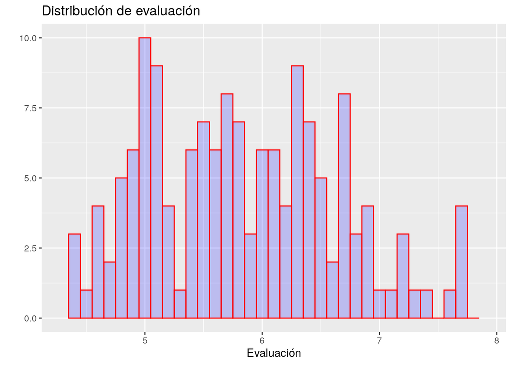

```r
#Usamos la librería ggplot2
qplot(evaluacion,
      geom="histogram",
      binwidth = 0.1,
      main = "Distribución de evaluación",
      xlab = "Evaluación",
      fill=I("blue"),
      col=I("red"),
      alpha=I(.2),
      xlim=c(4.3,7.9))
```

# GRAFICOS DE BARRAS Y PASTEL

Definimos la variable especies´ para generar directamente una distribución de frecuencias

```r
especie = iris$Species
tipo = table(especie)
tipo
```

```
## especie
##     setosa versicolor  virginica
##         50         50         50
```

Intentamos primero construir un gráfico de barras verticales, y luego lo reconstruimos a barras horizontales

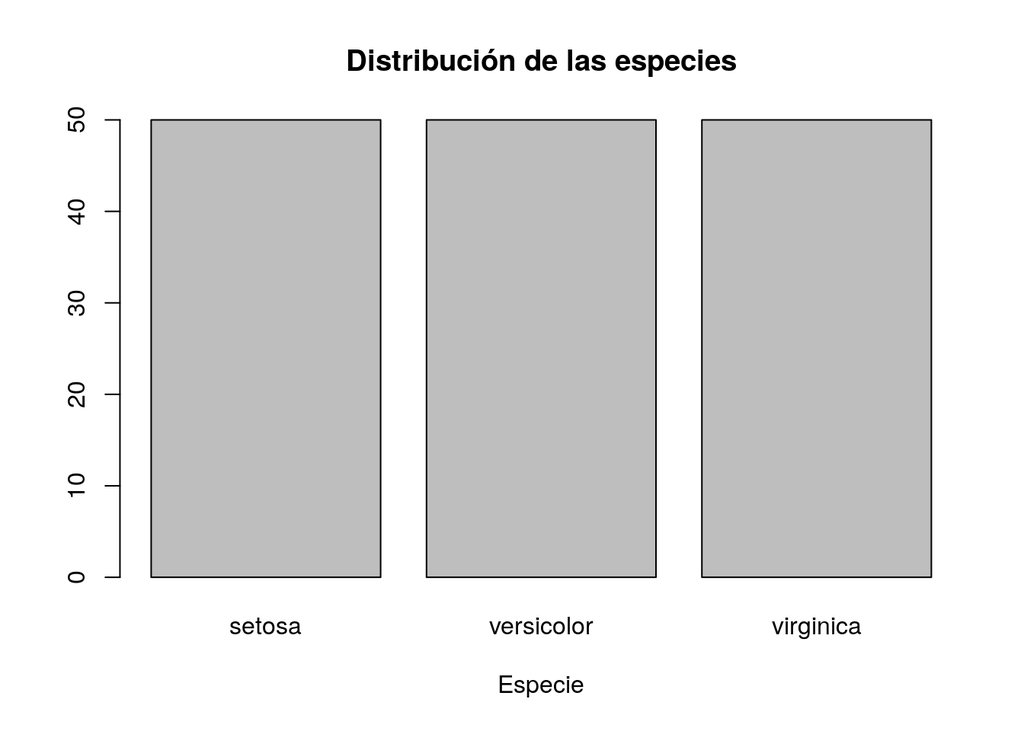

```r
barplot(tipo,
        main="Distribución de las especies",
        xlab="Especie")
```

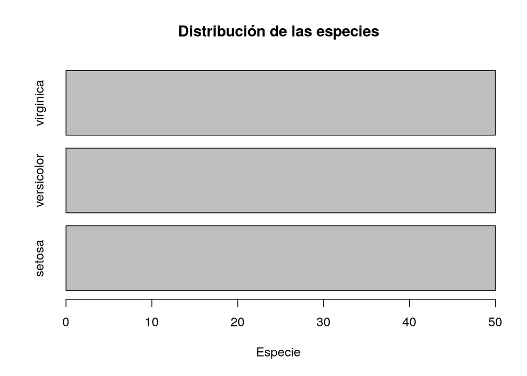

```r
barplot(tipo,
        main="Distribución de las especies",
        xlab="Especie",
        horiz=TRUE)
```

Calculamos las frecuencias relativas de esa variable

```r
porcentaje = round(tipo/sum(tipo)*100)
porcentaje
```

```
## especie
##     setosa versicolor  virginica
##         33         33         33
```

```r
nombres = rownames(porcentaje)
etiqueta = paste(nombres, porcentaje)
etiqueta = paste(etiqueta, "%", sep = " ")
```

Creamos un gráfico de pastel utilizando los porcentajes y las etiquetas creadas

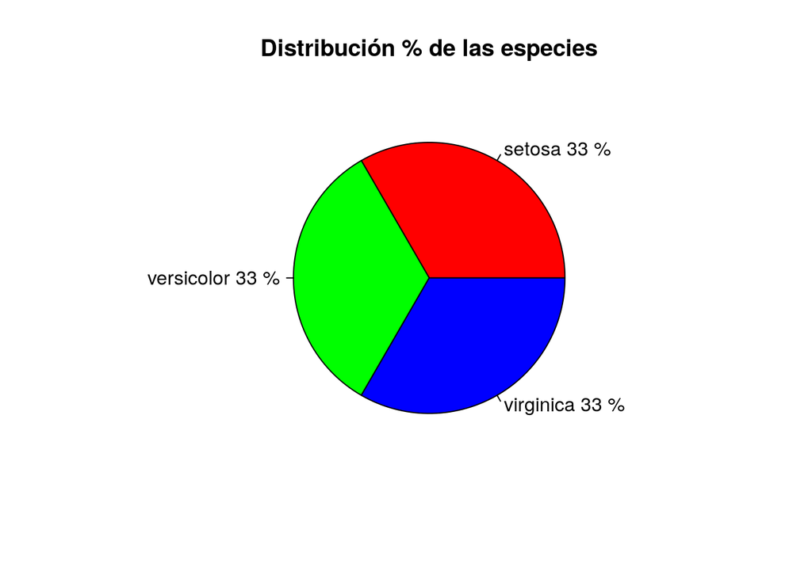

```r
pie(porcentaje, labels = etiqueta, col=rainbow(length(etiqueta)),
    main="Distribución % de las especies")
```

#Relación Cruzada